# Energy Prediction

## Introduction

This study looked into assessing the heating load and cooling load requirements of buildings (that is, energy efficiency) as a function of building parameters.

- Source:

The dataset was created by Angeliki Xifara (angxifara ‘@’ gmail.com, Civil/Structural Engineer) and was processed by Athanasios Tsanas (tsanasthanasis ‘@’ gmail.com, Oxford Centre for Industrial and Applied Mathematics, University of Oxford, UK).

- Data Set Information:

We perform energy analysis using 12 different building shapes simulated in Ecotect. The buildings differ with respect to the glazing area, the glazing area distribution, and the orientation, amongst other parameters. We simulate various settings as functions of the afore-mentioned characteristics to obtain 768 building shapes. The dataset comprises 768 samples and 8 features, aiming to predict two real valued responses. It can also be used as a multi-class classification problem if the response is rounded to the nearest integer.

- Attribute Information:

The dataset contains eight attributes (or features, denoted by X1…X8) and two responses (or outcomes, denoted by y1 and y2). The aim is to use the eight features to predict each of the two responses.

- Specifically:
1. X1 Relative Compactness
2. X2 Surface Area
3. X3 Wall Area
4. X4 Roof Area
5. X5 Overall Height
6. X6 Orientation
7. X7 Glazing Area
8. X8 Glazing Area Distribution
9. y1 Heating Load
10. y2 Cooling Load
- Relevant Papers:

A. Tsanas, A. Xifara: ‘Accurate quantitative estimation of energy performance of residential buildings using statistical machine learning tools’, Energy and Buildings, Vol. 49, pp. 560-567, 2012

- Citation Request:

A. Tsanas, A. Xifara: ‘Accurate quantitative estimation of energy performance of residential buildings using statistical machine learning tools’, Energy and Buildings, Vol. 49, pp. 560-567, 2012 (the paper can be accessed from [Web Link])

For further details on the data analysis methodology: A. Tsanas, ‘Accurate telemonitoring of Parkinsonâ€™s disease symptom severity using nonlinear speech signal processing and statistical machine learning’, D.Phil. thesis, University of Oxford, 2012 (which can be accessed from [Web Link])

## Load Data

```r
library(tidyverse)
```

```r
library(readxl)
library(ggplot2)
library(psych)
library(reshape2)
library(clusterSim) #normalization
library(cowplot)
```

load the dataset and view the first five rows

```r
df <- read_excel('./ENB2012_data.xlsx')
head(df)
```

```
## # A tibble: 6 x 10
##      X1    X2    X3    X4    X5    X6    X7    X8    Y1    Y2
##   <dbl> <dbl> <dbl> <dbl> <dbl> <dbl> <dbl> <dbl> <dbl> <dbl>
## 1 0.980   514   294   110  7.00  2.00     0     0  15.6  21.3
## 2 0.980   514   294   110  7.00  3.00     0     0  15.6  21.3
## 3 0.980   514   294   110  7.00  4.00     0     0  15.6  21.3
## 4 0.980   514   294   110  7.00  5.00     0     0  15.6  21.3
## 5 0.900   564   318   122  7.00  2.00     0     0  20.8  28.3
## 6 0.900   564   318   122  7.00  3.00     0     0  21.5  25.4
```

Get the summary statistics of the dataframe

```r
summary(df)
```

```
##        X1               X2              X3              X4
##  Min.   :0.6200   Min.   :514.5   Min.   :245.0   Min.   :110.2
##  1st Qu.:0.6825   1st Qu.:606.4   1st Qu.:294.0   1st Qu.:140.9
##  Median :0.7500   Median :673.8   Median :318.5   Median :183.8
##  Mean   :0.7642   Mean   :671.7   Mean   :318.5   Mean   :176.6
##  3rd Qu.:0.8300   3rd Qu.:741.1   3rd Qu.:343.0   3rd Qu.:220.5
##  Max.   :0.9800   Max.   :808.5   Max.   :416.5   Max.   :220.5
##        X5             X6             X7               X8
##  Min.   :3.50   Min.   :2.00   Min.   :0.0000   Min.   :0.000
##  1st Qu.:3.50   1st Qu.:2.75   1st Qu.:0.1000   1st Qu.:1.750
##  Median :5.25   Median :3.50   Median :0.2500   Median :3.000
##  Mean   :5.25   Mean   :3.50   Mean   :0.2344   Mean   :2.812
##  3rd Qu.:7.00   3rd Qu.:4.25   3rd Qu.:0.4000   3rd Qu.:4.000
##  Max.   :7.00   Max.   :5.00   Max.   :0.4000   Max.   :5.000
##        Y1              Y2
##  Min.   : 6.01   Min.   :10.90
##  1st Qu.:12.99   1st Qu.:15.62
##  Median :18.95   Median :22.08
##  Mean   :22.31   Mean   :24.59
##  3rd Qu.:31.67   3rd Qu.:33.13
##  Max.   :43.10   Max.   :48.03
```

From the summary statistics, we can see that there is no missing values. All the columns are numerics

Change the columns name to its meaningful names

```r
#create a vector of the columns
df_column <- c('Relative_Compactness','Surface_Area', 'Wall_Area','Roof_Area','Overall_Height','Orientation','Glazing_Area','Glazing_Area_Distribution','Heating_Load','Cooling_Load')

colnames(df) <- df_column

summary(df)
```

```
##  Relative_Compactness  Surface_Area     Wall_Area       Roof_Area
##  Min.   :0.6200       Min.   :514.5   Min.   :245.0   Min.   :110.2
##  1st Qu.:0.6825       1st Qu.:606.4   1st Qu.:294.0   1st Qu.:140.9
##  Median :0.7500       Median :673.8   Median :318.5   Median :183.8
##  Mean   :0.7642       Mean   :671.7   Mean   :318.5   Mean   :176.6
##  3rd Qu.:0.8300       3rd Qu.:741.1   3rd Qu.:343.0   3rd Qu.:220.5
##  Max.   :0.9800       Max.   :808.5   Max.   :416.5   Max.   :220.5
##  Overall_Height  Orientation    Glazing_Area    Glazing_Area_Distribution
##  Min.   :3.50   Min.   :2.00   Min.   :0.0000   Min.   :0.000
##  1st Qu.:3.50   1st Qu.:2.75   1st Qu.:0.1000   1st Qu.:1.750
##  Median :5.25   Median :3.50   Median :0.2500   Median :3.000
##  Mean   :5.25   Mean   :3.50   Mean   :0.2344   Mean   :2.812
##  3rd Qu.:7.00   3rd Qu.:4.25   3rd Qu.:0.4000   3rd Qu.:4.000
##  Max.   :7.00   Max.   :5.00   Max.   :0.4000   Max.   :5.000
##   Heating_Load    Cooling_Load
##  Min.   : 6.01   Min.   :10.90
##  1st Qu.:12.99   1st Qu.:15.62
##  Median :18.95   Median :22.08
##  Mean   :22.31   Mean   :24.59
##  3rd Qu.:31.67   3rd Qu.:33.13
##  Max.   :43.10   Max.   :48.03
```

Pair plot for the correlation of the dataframe

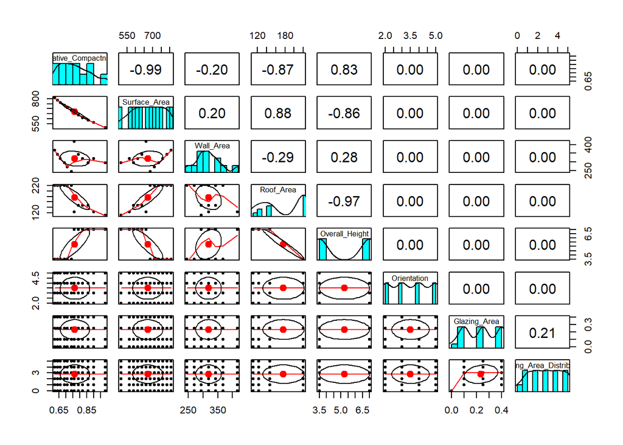

```r
pairs.panels(df[,-c(9,10)])
```

- The roof_Area and Overall_height are higly corelated with corelation of -0.97
- The ralatic compactiness and surface area are higly corelated with corelation of -0.99

Let take a close look at the correlation between this two pairs of variables

```r
cor.test(df$Overall_Height, df$Roof_Area)
```

```
##
##  Pearson's product-moment correlation
##
## data:  df$Overall_Height and df$Roof_Area
## t = -115.59, df = 766, p-value < 2.2e-16
## alternative hypothesis: true correlation is not equal to 0
## 95 percent confidence interval:
##  -0.9761011 -0.9683931
## sample estimates:
##        cor
## -0.9725122
```

At 95% confidence the correlation is between -0.9761011 and -0.9683931. This two variables are strongly correlated

```r
cor.test(df$Relative_Compactness, df$Surface_Area)
```

```
##
##  Pearson's product-moment correlation
##
## data:  df$Relative_Compactness and df$Surface_Area
## t = -216.15, df = 766, p-value < 2.2e-16
## alternative hypothesis: true correlation is not equal to 0
## 95 percent confidence interval:
##  -0.9929678 -0.9906741
## sample estimates:
##        cor
## -0.9919015
```

relative compactiness and surface area strongly correlated with 95% confidence of between -0.9929678 and -.09906741

## Data distribution

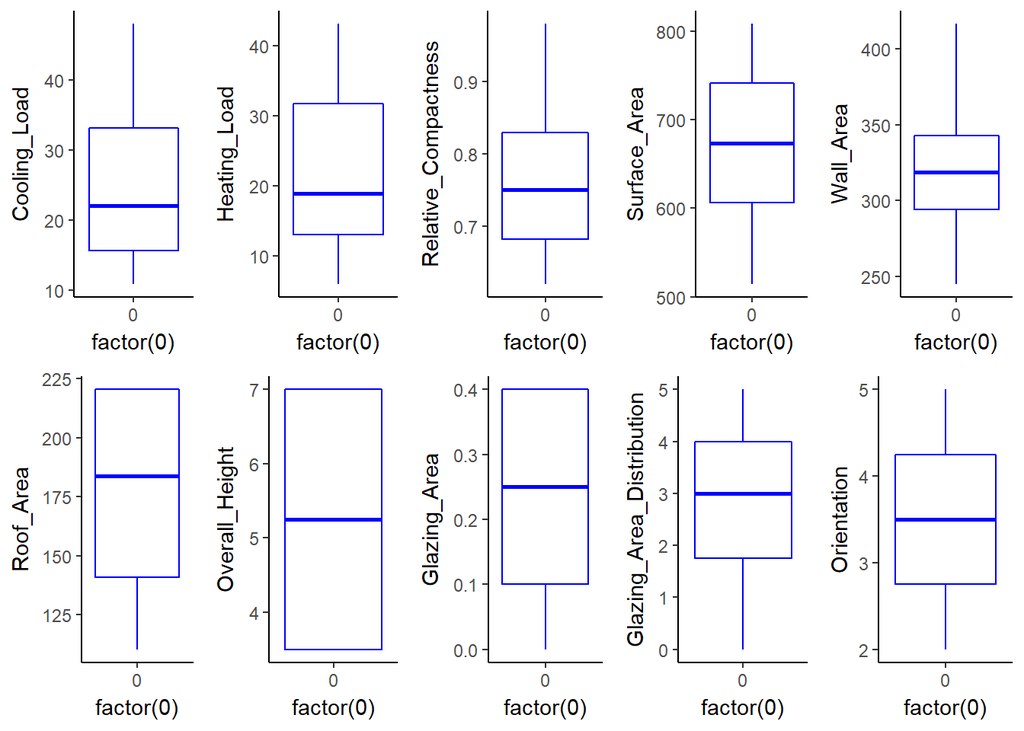

```r
g <- ggplot(df, aes(x=factor(0),Cooling_Load)) + geom_boxplot(color = 'blue') + theme_classic()
h <- ggplot(df, aes(x=factor(0),Heating_Load)) + geom_boxplot(color = 'blue') + theme_classic()
i <- ggplot(df, aes(x=factor(0),Relative_Compactness)) + geom_boxplot(color = 'blue') + theme_classic()
j <- ggplot(df, aes(x=factor(0),Surface_Area)) + geom_boxplot(color = 'blue') + theme_classic()
k <- ggplot(df, aes(x=factor(0),Wall_Area)) + geom_boxplot(color = 'blue') + theme_classic()
l <- ggplot(df, aes(x=factor(0),Roof_Area)) + geom_boxplot(color = 'blue') + theme_classic()
m <- ggplot(df, aes(x=factor(0),Overall_Height)) + geom_boxplot(color = 'blue') + theme_classic()
n <- ggplot(df, aes(x=factor(0),Glazing_Area)) + geom_boxplot(color = 'blue') + theme_classic()
o <- ggplot(df, aes(x=factor(0),Glazing_Area_Distribution)) + geom_boxplot(color = 'blue') + theme_classic()
p <- ggplot(df, aes(x=factor(0),Orientation)) + geom_boxplot(color = 'blue') + theme_classic()

plot_grid(g,h,i,j,k,l,m,n,o,p,nrow = 2, ncol = 5)
```

Check if there is relationship between the two target variables

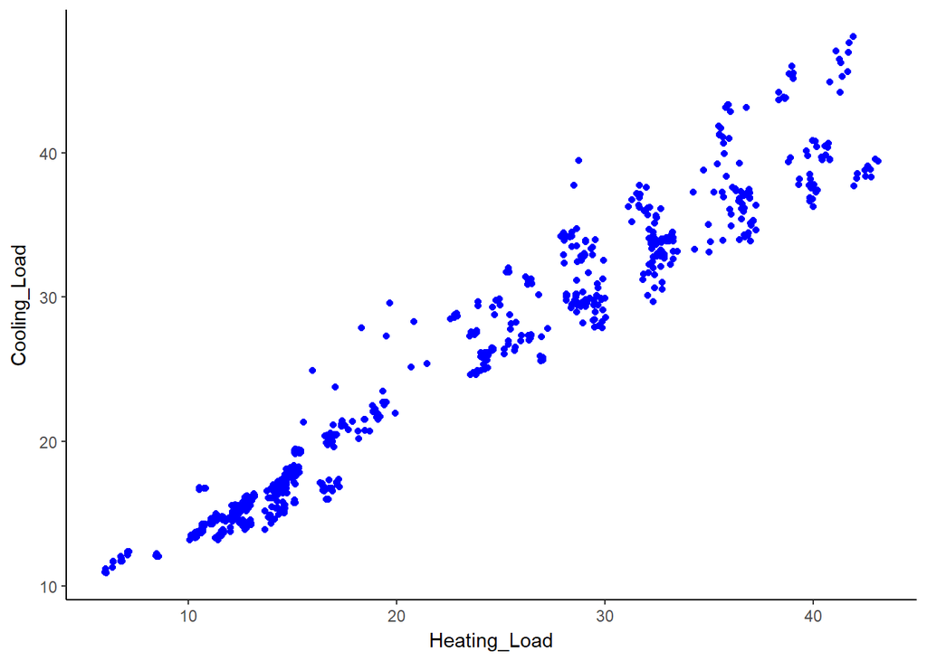

```r
ggplot(df, aes(x=Heating_Load, y=Cooling_Load)) + geom_point(color='blue') + theme_classic()
```

There is a linear relationship between the two target variables.

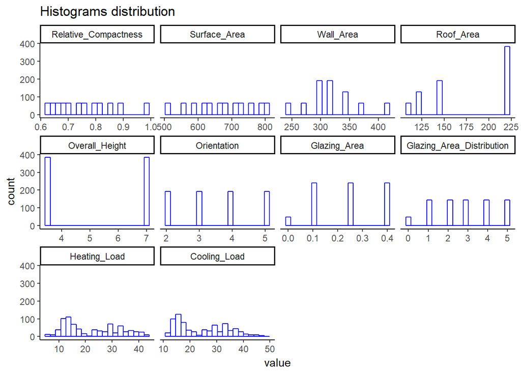

```r
g <- ggplot(data=melt(df), aes(x=value)) + geom_histogram(bins = 20,color='blue', fill ='white') + facet_wrap(~variable, scales = 'free_x') + theme_classic()
g <- g + ggtitle('Histograms distribution')
g
```

## Baseline Model using random forest

```r
library(randomForest)
```

```r
#split datasets input features and target

M1 <- df[,-10]  #heating
m2 <- df[,-9] #cooling
```

Build the model

### Heating Load

```r
#heating load

rf_heating <- randomForest(Heating_Load ~ ., data = M1, mtry=3, importance = TRUE, na.action = na.omit)

rf_heating
```

```
##
## Call:
##  randomForest(formula = Heating_Load ~ ., data = M1, mtry = 3,      importance = TRUE, na.action = na.omit)
##                Type of random forest: regression
##                      Number of trees: 500
## No. of variables tried at each split: 3
##
##           Mean of squared residuals: 0.453421
##                     % Var explained: 99.55
```

Feature importatnce

```r
rf_heating$importance
```

```
##                              %IncMSE IncNodePurity
## Relative_Compactness      64.4097764   21388.39986
## Surface_Area              45.6084567   13973.84556
## Wall_Area                 12.8558965    3756.81208
## Roof_Area                 50.3871131   14778.35688
## Overall_Height            57.0157579   16861.01435
## Orientation               -0.1666216      52.04629
## Glazing_Area              11.3711219    4477.71383
## Glazing_Area_Distribution  3.5151918    1784.54547
```

The orientation and grazing area distribution has the lowest contribution to the prediction of heating load

### cooling

```r
rf_cooling <- randomForest(Cooling_Load ~ ., data = m2, mtry=3, importance = TRUE, na.action = na.omit)
rf_cooling
```

```
##
## Call:
##  randomForest(formula = Cooling_Load ~ ., data = m2, mtry = 3,      importance = TRUE, na.action = na.omit)
##                Type of random forest: regression
##                      Number of trees: 500
## No. of variables tried at each split: 3
##
##           Mean of squared residuals: 3.036774
##                     % Var explained: 96.64
```

```r
rf_cooling$importance
```

```
##                              %IncMSE IncNodePurity
## Relative_Compactness      47.1287465    14994.7181
## Surface_Area              58.1586362    19169.7349
## Wall_Area                 12.4162686     3542.2599
## Roof_Area                 46.9078996    14557.8158
## Overall_Height            37.1644564    11703.2860
## Orientation                0.1094144      245.8483
## Glazing_Area               5.5115880     2429.4616
## Glazing_Area_Distribution  1.0857750      825.6322
```

Orientation and grazing area distribution has the lowest contribution

## Build a baseline model using Linear Regression

### heating

```r
lm_heating <- lm(Heating_Load ~.,data = M1)

summary(lm_heating)
```

```
##
## Call:
## lm(formula = Heating_Load ~ ., data = M1)
##
## Residuals:
##     Min      1Q  Median      3Q     Max
## -9.8965 -1.3196 -0.0252  1.3532  7.7052
##
## Coefficients: (1 not defined because of singularities)
##                             Estimate Std. Error t value Pr(>|t|)
## (Intercept)                84.013418  19.033613   4.414 1.16e-05 ***
## Relative_Compactness      -64.773432  10.289448  -6.295 5.19e-10 ***
## Surface_Area               -0.087289   0.017075  -5.112 4.04e-07 ***
## Wall_Area                   0.060813   0.006648   9.148  < 2e-16 ***
## Roof_Area                         NA         NA      NA       NA
## Overall_Height              4.169954   0.337990  12.338  < 2e-16 ***
## Orientation                -0.023330   0.094705  -0.246  0.80548
## Glazing_Area               19.932736   0.813986  24.488  < 2e-16 ***
## Glazing_Area_Distribution   0.203777   0.069918   2.915  0.00367 **
## ---
## Signif. codes:  0 '***' 0.001 '**' 0.01 '*' 0.05 '.' 0.1 ' ' 1
##
## Residual standard error: 2.934 on 760 degrees of freedom
## Multiple R-squared:  0.9162, Adjusted R-squared:  0.9154
## F-statistic:  1187 on 7 and 760 DF,  p-value: < 2.2e-16
```

```r
anova(lm_heating)
```

```
## Analysis of Variance Table
##
## Response: Heating_Load
##                            Df  Sum Sq Mean Sq   F value    Pr(>F)
## Relative_Compactness        1 30238.2 30238.2 3511.8926 < 2.2e-16 ***
## Surface_Area                1  8092.8  8092.8  939.9113 < 2.2e-16 ***
## Wall_Area                   1 26144.8 26144.8 3036.4862 < 2.2e-16 ***
## Overall_Height              1  1310.6  1310.6  152.2140 < 2.2e-16 ***
## Orientation                 1     0.5     0.5    0.0607  0.805480
## Glazing_Area                1  5686.1  5686.1  660.3875 < 2.2e-16 ***
## Glazing_Area_Distribution   1    73.1    73.1    8.4944  0.003667 **
## Residuals                 760  6543.8     8.6
## ---
## Signif. codes:  0 '***' 0.001 '**' 0.01 '*' 0.05 '.' 0.1 ' ' 1
```

### Cooling

```r
lm_cooling <- lm(Cooling_Load ~ ., data = m2)
summary(lm_cooling)
```

```
##
## Call:
## lm(formula = Cooling_Load ~ ., data = m2)
##
## Residuals:
##     Min      1Q  Median      3Q     Max
## -8.6940 -1.5606 -0.2668  1.3968 11.1775
##
## Coefficients: (1 not defined because of singularities)
##                             Estimate Std. Error t value Pr(>|t|)
## (Intercept)                97.245749  20.764711   4.683 3.34e-06 ***
## Relative_Compactness      -70.787707  11.225269  -6.306 4.85e-10 ***
## Surface_Area               -0.088245   0.018628  -4.737 2.59e-06 ***
## Wall_Area                   0.044682   0.007253   6.161 1.17e-09 ***
## Roof_Area                         NA         NA      NA       NA
## Overall_Height              4.283843   0.368730  11.618  < 2e-16 ***
## Orientation                 0.121510   0.103318   1.176    0.240
## Glazing_Area               14.717068   0.888018  16.573  < 2e-16 ***
## Glazing_Area_Distribution   0.040697   0.076277   0.534    0.594
## ---
## Signif. codes:  0 '***' 0.001 '**' 0.01 '*' 0.05 '.' 0.1 ' ' 1
##
## Residual standard error: 3.201 on 760 degrees of freedom
## Multiple R-squared:  0.8878, Adjusted R-squared:  0.8868
## F-statistic: 859.1 on 7 and 760 DF,  p-value: < 2.2e-16
```

```r
anova(lm_cooling)
```

```
## Analysis of Variance Table
##
## Response: Cooling_Load
##                            Df  Sum Sq Mean Sq   F value Pr(>F)
## Relative_Compactness        1 27931.9 27931.9 2725.6959 <2e-16 ***
## Surface_Area                1  8254.2  8254.2  805.4720 <2e-16 ***
## Wall_Area                   1 21052.3 21052.3 2054.3534 <2e-16 ***
## Overall_Height              1  1383.2  1383.2  134.9739 <2e-16 ***
## Orientation                 1    14.2    14.2    1.3832 0.2399
## Glazing_Area                1  2988.9  2988.9  291.6699 <2e-16 ***
## Glazing_Area_Distribution   1     2.9     2.9    0.2847 0.5938
## Residuals                 760  7788.2    10.2
## ---
## Signif. codes:  0 '***' 0.001 '**' 0.01 '*' 0.05 '.' 0.1 ' ' 1
```

## Train a baseline model without Orientation and Grazing_Area_Distribution

```r
Mh <- df[,-c(6,8,10)]  # heating without orientation and grazing area distribution
Mc <- df[,-c(6,8,9)] # cooling
```

## Linear Model

### heating

```r
lm_heating2 <- lm(Heating_Load ~., data = Mh)

summary(lm_heating2)
```

```
##
## Call:
## lm(formula = Heating_Load ~ ., data = Mh)
##
## Residuals:
##      Min       1Q   Median       3Q      Max
## -10.3862  -1.3667  -0.0142   1.3162   7.5555
##
## Coefficients: (1 not defined because of singularities)
##                        Estimate Std. Error t value Pr(>|t|)
## (Intercept)           84.386471  19.111765   4.415 1.15e-05 ***
## Relative_Compactness -64.773432  10.333611  -6.268 6.11e-10 ***
## Surface_Area          -0.087289   0.017149  -5.090 4.51e-07 ***
## Wall_Area              0.060813   0.006676   9.109  < 2e-16 ***
## Roof_Area                    NA         NA      NA       NA
## Overall_Height         4.169954   0.339441  12.285  < 2e-16 ***
## Glazing_Area          20.437968   0.798727  25.588  < 2e-16 ***
## ---
## Signif. codes:  0 '***' 0.001 '**' 0.01 '*' 0.05 '.' 0.1 ' ' 1
##
## Residual standard error: 2.947 on 762 degrees of freedom
## Multiple R-squared:  0.9153, Adjusted R-squared:  0.9147
## F-statistic:  1646 on 5 and 762 DF,  p-value: < 2.2e-16
```

```r
anova(lm_heating2)
```

```
## Analysis of Variance Table
##
## Response: Heating_Load
##                       Df  Sum Sq Mean Sq F value    Pr(>F)
## Relative_Compactness   1 30238.2 30238.2 3481.94 < 2.2e-16 ***
## Surface_Area           1  8092.8  8092.8  931.89 < 2.2e-16 ***
## Wall_Area              1 26144.8 26144.8 3010.59 < 2.2e-16 ***
## Overall_Height         1  1310.6  1310.6  150.92 < 2.2e-16 ***
## Glazing_Area           1  5686.1  5686.1  654.75 < 2.2e-16 ***
## Residuals            762  6617.4     8.7
## ---
## Signif. codes:  0 '***' 0.001 '**' 0.01 '*' 0.05 '.' 0.1 ' ' 1
```

### cooling

```r
lm_cooling2 <- lm(Cooling_Load ~.,data = Mc)
summary(lm_cooling2)
```

```
##
## Call:
## lm(formula = Cooling_Load ~ ., data = Mc)
##
## Residuals:
##     Min      1Q  Median      3Q     Max
## -8.7240 -1.6017 -0.2631  1.3417 11.3251
##
## Coefficients: (1 not defined because of singularities)
##                        Estimate Std. Error t value Pr(>|t|)
## (Intercept)           97.761848  20.756339   4.710 2.94e-06 ***
## Relative_Compactness -70.787707  11.222822  -6.307 4.80e-10 ***
## Surface_Area          -0.088245   0.018624  -4.738 2.57e-06 ***
## Wall_Area              0.044682   0.007251   6.162 1.16e-09 ***
## Roof_Area                    NA         NA      NA       NA
## Overall_Height         4.283843   0.368650  11.620  < 2e-16 ***
## Glazing_Area          14.817971   0.867458  17.082  < 2e-16 ***
## ---
## Signif. codes:  0 '***' 0.001 '**' 0.01 '*' 0.05 '.' 0.1 ' ' 1
##
## Residual standard error: 3.2 on 762 degrees of freedom
## Multiple R-squared:  0.8876, Adjusted R-squared:  0.8868
## F-statistic:  1203 on 5 and 762 DF,  p-value: < 2.2e-16
```

```r
anova(lm_cooling2)
```

```
## Analysis of Variance Table
##
## Response: Cooling_Load
##                       Df  Sum Sq Mean Sq F value    Pr(>F)
## Relative_Compactness   1 27931.9 27931.9 2726.88 < 2.2e-16 ***
## Surface_Area           1  8254.2  8254.2  805.82 < 2.2e-16 ***
## Wall_Area              1 21052.3 21052.3 2055.25 < 2.2e-16 ***
## Overall_Height         1  1383.2  1383.2  135.03 < 2.2e-16 ***
## Glazing_Area           1  2988.9  2988.9  291.80 < 2.2e-16 ***
## Residuals            762  7805.3    10.2
## ---
## Signif. codes:  0 '***' 0.001 '**' 0.01 '*' 0.05 '.' 0.1 ' ' 1
```

Feature importatnce

```r
rf_heating$importance
```

```
##                              %IncMSE IncNodePurity
## Relative_Compactness      64.4097764   21388.39986
## Surface_Area              45.6084567   13973.84556
## Wall_Area                 12.8558965    3756.81208
## Roof_Area                 50.3871131   14778.35688
## Overall_Height            57.0157579   16861.01435
## Orientation               -0.1666216      52.04629
## Glazing_Area              11.3711219    4477.71383
## Glazing_Area_Distribution  3.5151918    1784.54547
```